# Determine the Congestion Charge Zone of New York with Prescriptive Analytics

## What is a congestion charge and why?

The London congestion charge is a fee charged on most motor vehicles operating within the Congestion Charge Zone (CCZ) in Central London between 07:00 and 18:00 Mondays to Fridays.

The charge aims to reduce high traffic flow in the central area and raise investment funds for London's transport system.

After ten years since its implementation in 2003, congestion charging scheme resulted in a 10% reduction in traffic volumes from baseline conditions, and an overall reduction of 11% in vehicle.

See https://en.wikipedia.org/wiki/London_congestion_charge

```python
from IPython.display import Image
Image(url='http://content.tfl.gov.uk/congestion-charge-zone-map.gif', width=600, height=400)
```

[figure not shown]

### What does it mean to apply it to New York?

We can use open data: it means handling big data files (taxis trips for each month of 2014 is a 1GB csv file). We will use:

- pandas to do all the data clean up and split the trips in city block.
- geospatial open source library to keep the interesting tris in/out of Mahnattan
- docplex to determine the CCZ area
- google maps to visualize the solution

```python
import tempfile
import os

mydir = tempfile.gettempdir()
csv = "trip_data_1.csv"
ff = csv+".zip"
fullzip = mydir+os.path.sep+ff
fullcsv = mydir+os.path.sep+csv
os.path.normpath(fullzip)
os.path.normpath(fullcsv)
print(fullcsv)
```

```
c:\users\vberaudi\appdata\local\temp\trip_data_1.csv
```

Get the file only if needed (1GB in ~1h). We get it only once.

```python
import requests
if os.path.exists(fullzip) is False:
    url = "https://nyctaxitrips.blob.core.windows.net/data/"+ff
    r = requests.get(url)
    with open(fullzip, "wb") as code:
        code.write(r.content)
```

Unzip only if needed

```python
if os.path.exists(fullzip) is False:
    import zipfile
    with zipfile.ZipFile(fullzip) as zf:
        zf.extractall(mydir)
```

Read the CSV: we will use pandas to do all the big data clean up and preparation

```python
import pandas as pd
import os
```

```python
ft = pd.read_csv(fullcsv)
```

```python
databegin = len(ft)
print("We have " +str(databegin)+" trips in New York in January")
```

```
We have 14776615 trips in New York in January
```

### We need to remove the noise: some bad data with 0 km trips, impossible gps coordinates...

First drop some useless columns to gain memory

```python
cols = [c.strip() for c in list(ft.columns.values)]
ft.columns = cols
mycols = {'pickup_datetime', 'dropoff_datetime', 'passenger_count', 'trip_time_in_secs', 'trip_distance', 'pickup_longitude', 'pickup_latitude', 'dropoff_longitude', 'dropoff_latitude'}
for c in cols:
    if c not in mycols:
        ft.drop(c, 1)
```

Remove null trips.

```python
if 'pickup_datetime' in cols and 'dropoff_datetime' in cols:
    ft = ft[ft['pickup_datetime'] != ft['dropoff_datetime']]
if 'trip_distance' in cols:
    ft = ft[ft['trip_distance'] != 0]
if 'total_amount' in cols:
    ft = ft[ft['total_amount'] != 0]
print("we removed "+str(databegin-len(ft))+" bad records")
```

```
we removed 93495 bad records
```

Data is not clean: some latitude and longitude point to North Pole !

```python
ft = ft[ft['pickup_longitude'] < -73]
ft = ft[ft['pickup_longitude'] > -76]
ft = ft[ft['pickup_latitude'] > 39]
ft = ft[ft['pickup_latitude'] < 43]
print("we removed "+str(databegin-len(ft))+" bad records so far")
```

```
we removed 340976 bad records so far
```

```python
ft = ft[ft['dropoff_longitude'] <-73]
ft = ft[ft['dropoff_longitude'] >-76]
ft = ft[ft['dropoff_latitude'] >39]
ft = ft[ft['dropoff_latitude'] <43]
```

```python
print("we removed "+str(databegin-len(ft))+" bad records so far")
```

```
we removed 353522 bad records so far
```

The tax should not be done on co-driving

```python
if 'passenger_count' in cols:
    ft = ft[ft['passenger_count'] <= 3]
print("we removed "+str(databegin-len(ft))+" bad records so far")
```

```
we removed 2038791 bad records so far
```

### We focus on manhatan: use geodetic computation python lib to keep only the trips that will end up in Manhattan while started outside of Manhattan

- https://pypi.python.org/pypi/pyshp/
- https://pypi.python.org/pypi/pyproj
- https://pypi.python.org/pypi/Pillow/

```python
!pip install pyshp
```

```
You are using pip version 7.0.3, however version 7.1.2 is available.
```

```python
!pip install pyproj
```

```
You are using pip version 7.0.3, however version 7.1.2 is available.
```

```python
!pip install pillow
```

```
You are using pip version 7.0.3, however version 7.1.2 is available.
```

```python
import pyproj

NAD_1983_StatePlane_New_York_Long_Island_FIPS_3104_Feet = "+proj=lcc +lat_1=40.66666666666666 +lat_2=41.03333333333333 +lat_0=40.16666666666666 +lon_0=-74 +x_0=300000.00000000 +y_0=0 +ellps=GRS80 +datum=NAD83 +to_meter=0.3048006096012192 +no_defs"

map_prj = pyproj.Proj(NAD_1983_StatePlane_New_York_Long_Island_FIPS_3104_Feet, preserve_units=True)
wgs84 = pyproj.Proj("+proj=longlat +ellps=WGS84 +datum=WGS84 +no_def")

class Poly:
    def __init__(self):
        self.bbox = None
        self.rings = [] # list of polys !
    def populate(self, m, src_proj, target_proj): # m is a shape record
        print m.shape
        maxcount = len(m.shape.parts)-1
        for i,lb in enumerate(m.shape.parts):
            ub = (m.shape.parts[i+1]-1) if i<maxcount else None
            ring = list(m.shape.points[lb:ub])
            sarea = shapefile.signed_area(ring)
            # exclude holes
            if sarea <0:
                projected = [pyproj.transform(src_proj, target_proj, po[0],po[1]) for po in ring]
                self.rings.append(projected)
        # once projected, compute bbox
        (minx,miny) = self.rings[0][0]
        (maxx,maxy) = (minx,miny)
        for ring in self.rings:
            for (x,y) in ring:
                if x < minx:
                    minx = x
                if x > maxx:
                    maxx = x
                if y < miny:
                    miny = y
                if y > maxy:
                    maxy = y
        self.bbox= [minx, miny, maxx, maxy]

    def point_inside_ring(self,x,y,poly):
        n = len(poly)
        inside =False
        p1x,p1y = poly[0]
        for i in range(n+1):
            p2x,p2y = poly[i % n]
            if y > min(p1y,p2y):
                if y <= max(p1y,p2y):
                    if x <= max(p1x,p2x):
                        if p1y != p2y:
                            xinters = (y-p1y)*(p2x-p1x)/(p2y-p1y)+p1x
                        if p1x == p2x or x <= xinters:
                            inside = not inside
            p1x,p1y = p2x,p2y
        return inside

    def contains(self,x,y):
        bbox = self.bbox
        if x < bbox[0] or x > bbox[2] or y < bbox[1] or y > bbox[3]:
            return False
        for ring in self.rings:
            if self.point_inside_ring(x,y, ring):
                return True
        return False
```

We know that we have: polygon index => name 0 => Staten Island 1 => Bronx 2 => Manhattan 3 => Brooklyn 4 => Queens Let's create a list of polygon:

Get the New York data only if needed from open source projects of NY

```python
myzip = "nybb_15c"
pyshp  = "http://www.nyc.gov/html/dcp/download/bytes/"+myzip+".zip"

fullzip = mydir+os.path.sep+myzip+".zip"

import requests
import os

if os.path.exists(fullzip) is False:
    r = requests.get(pyshp)
    with open(fullzip, "wb") as code:
        code.write(r.content)
    import zipfile
    with zipfile.ZipFile(fullzip) as zf:
        zf.extractall(mydir)
```

We will keep only Manhattan block

```python
import shapefile
ff = mydir+os.path.sep+myzip+os.path.sep+"nybb.shp"
print(ff)
sf = shapefile.Reader(ff)

sr= sf.shapeRecords()

# Select polygons we want
keep = [x for x in sr if x.record[1] == 'Manhattan']
```

```
c:\users\vberaudi\appdata\local\temp\nybb_15c\nybb.shp
```

Convert shapes to lon/lat. That also create polys and bbox, the list of polygons to keep and the list of bounding box

```python
keep_polys = []
for k in keep:
    kpoly = Poly()
    kpoly.populate(k, map_prj, wgs84)
    keep_polys.append(kpoly)
```

```
<shapefile._Shape instance at 0x0000000065C54B48>
```

```python
from PIL import Image, ImageDraw

MASK_SIZE = (1000,1000)

class Intersector:
    def __init__(self, polys):
        self.polys = polys # list of polygons !
        self.masks = []
        self.create_masks()

    def icoord(self, bb, c):
        (x,y) = c
        (w,h) = MASK_SIZE
        minx = bb[0]
        miny = bb[1]
        maxx = bb[2]
        maxy = bb[3]
        dx = maxx - minx
        dy = maxy - miny

        i = round(w * ((x - minx)/dx))
        j = round(h * ((y - miny)/dy))

        if i<0:
            i=0
        if j<0:
            j=0
        if i>=w:
            i=w
        if j>=h:
            j=h
        return (i,j)

    def simplify(self, pp):
        n = []
        last = None
        for p in pp:
            if last is None:
                last = p
                n.append(p)
            else:
                if p != last:
                    last = p
                    n.append(p)
        return n

    def create_masks(self):
        for poly in self.polys:
            bb = poly.bbox
            im = Image.new('L', MASK_SIZE, 0)
            (w,h) = MASK_SIZE
            for ring in poly.rings:
                pp = [self.icoord(bb, point) for point in ring]
                pp = self.simplify(pp)
                # draw that in im
                draw = ImageDraw.Draw(im)
                draw.polygon(pp,fill=0xffffff,outline=0xffffff)
            self.masks.append(im)
            #im.show()


    def keep_point(self,x,y, fast=True):
        if fast:
            # fast mode using bitmap
            for imask, mask in enumerate(self.masks):
                pol = self.polys[imask]
                (x,y) = self.icoord(pol.bbox, (x,y))
                (w,h) = MASK_SIZE
                if  (x>=0) and (x<w) and (y>=0) and (y<h):
                    if mask.getpixel((x,y)) != 0:
                        return True
        else:
            # slow geometric mode
            for poly in self.polys:
                if poly.contains(x,y):
                    return True
        return False
```

This is a quick point inside polygon function:

We now iterate on all the trips and keep only those which ended up in Manhattan: add a flag column on the trip DataFrame in pandas.

```python
intersector = Intersector(keep_polys)
keeper = [True for k in ft.index]
idx = 0
for i in ft.index:
    lat = ft.ix[i, 'dropoff_latitude']
    lon = ft.ix[i, 'dropoff_longitude']
    k = intersector.keep_point(lon, lat)
    if k is False:
        keeper[idx] = k
    idx +=1
    if i%1000000 == 0:
        print(str(i))
ft['keep'] = keeper
```

```
1000000
2000000
3000000
4000000
5000000
6000000
7000000
8000000
11000000
12000000
13000000
14000000
```

We remove the bad trips

```python
ft = ft.query('keep==True')
```

```python
dataend = len(ft)
print "we removed " + str(databegin-dataend) + " entries so far"
print "playing with " + str(dataend) + " entries"
```

```
we removed 3364694 entries so far
playing with 11411921 entries
```

Same thing with pickups that must occur outside of Manhattan

```python
keeper = [False for k in ft.index]
idx = 0
for i in ft.index:
    lat = ft.ix[i, 'pickup_latitude']
    lon = ft.ix[i, 'pickup_longitude']
    k = intersector.keep_point(lon, lat)
    if k is True:
        keeper[idx] = k
    idx +=1
    if i%1000000 == 0:
        print(str(i))
ft['keep'] = keeper
```

```
1000000
2000000
3000000
4000000
5000000
6000000
8000000
11000000
12000000
13000000
14000000
```

```python
ft = ft.query('keep==False')
```

```python
dataend = len(ft)
print "we removed " + str(databegin-dataend) + " entries so far"
print "playing with " + str(dataend) + " entries"
```

```
we removed 14317167 entries so far
playing with 459448 entries
```

Let's get the min/max GPS coordinates to slice the maps into several squares

```python
longmin = ft['dropoff_longitude'].min()
longmax = ft['dropoff_longitude'].max()
latmin = ft['dropoff_latitude'].min()
latmax = ft['dropoff_latitude'].max()
latdiff = latmax - latmin
longdiff = longmax - longmin
print latmin
print longmin
print latmax
print longmax
```

```
40.613743
-74.303925
40.877857
-73.907188
```

Do the sampling.

```python
sampling= 90
latsampling = latdiff/sampling
longsampling = longdiff/sampling
print latsampling
print longsampling

mytuple = (latmin, latmax, longmin, longmax, latsampling, longsampling, sampling)
```

```
0.0029346
0.00440818888889
```

```python
hit_table = []
nbtot = 0
for i in range(14, sampling):
    sub = ft.query('dropoff_latitude>=' + str(latmin+latsampling*i))
    sub = sub.query('dropoff_latitude<' + str(latmin+latsampling*(i+1)))
    for j in range(0, sampling):
        sub2= sub.query('dropoff_longitude>=' + str(longmin+longsampling*j))
        sub2= sub2.query('dropoff_longitude<' + str(longmin+longsampling*(j+1)))
        if len(sub2) != 0:
            hit_table.append((i, j, len(sub2)))
            nbtot = nbtot+len(sub2)
        #print nbtot
assert nbtot <= dataend
print nbtot
```

```
459411
```

```python
matrix = pd.DataFrame(data = hit_table, columns=['i','j','nb'])
mean = matrix['nb'].mean()
#maxi = matrix['nb'].max()
#mini = matrix['nb'].min()
#print(mean)
#print(mini)
#print(maxi)

# no need to optimize areas with very few trips.
matrix = matrix[ matrix['nb'] > 2 ]
hit_table = [(t[1], t[2], t[3]) for t in matrix.itertuples()]
```

Let's see the distribution of the trips per blocks. Obviously CCZ will be located where a lot of trips will occur: we display only the trips >= the mean

```python
%%html
<style type="text/css">
  .map-canvas { height: 700px; }
</style>
```

```python
hit_table_sub = [t for t in hit_table if t[2] >= mean]
ppxs = [p[0] for p in hit_table_sub]
ppys = [p[1] for p in hit_table_sub]
```

```python
from IPython.core.display import HTML, Javascript
def gmap_init():
    js = """
window.gmap_initialize = function() {};
$.getScript('https://maps.googleapis.com/maps/api/js?v=3&sensor=false&callback=gmap_initialize');
"""
    return Javascript(data=js)

gmap_init()
```

Let's create a google map to check if filtered adequately and only kept Manhattan

[figure not shown]

```python
# generate a random id
import uuid
div_id = 'i' + str(uuid.uuid4())

html = """<div height="700" width="500" id="%s" class="map-canvas"/>""" % (div_id)
js = """<script type="text/Javascript">
  (function(){
		var centerlatlng = new google.maps.LatLng(40.759560, -73.978526);
		var myOptions = {
			zoom: 13,
			center: centerlatlng,
			mapTypeId: google.maps.MapTypeId.ROADMAP
		};
		var map = new google.maps.Map(document.getElementById('%s'), myOptions);"""% (div_id)

for toll in hit_table_sub:
    if toll[2] >= mean:
        ii = toll[0]
        jj = toll[1]
        lt = latmin + latsampling*ii
        lg = longmin + longsampling*jj
        sub = "var latlng = new google.maps.LatLng("+str(lt)+", "+str(lg)+");"
        js += sub
        js += """
        var img = new google.maps.MarkerImage('http://chart.apis.google.com/chart?cht=mm&chs=12x16&chco=FFFFFF,0000FF,000000&ext=.png');
            var marker = new google.maps.Marker({
            title: "no implimentation",
            icon: img,
            position: latlng
            });
            marker.setMap(map);
        """
js += """})();
</script>
"""

HTML(html+js)
```

Let's use a simple scatter with different color depending on the number of trips. We will then be able to visually see where the CCZ will be located (obvisouly where a lot of red can be found)

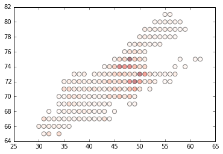

```python
import matplotlib.pyplot as plt
%matplotlib inline

plt.cla()
pcolors = [(p[2]*256//maxi) for p in hit_table_sub]

plt.scatter(ppxs, ppys, c=pcolors, cmap="Reds", s = 50, alpha=0.5)


plt.show()
```

# we are ready to optimize

Let's install CPLEX for python

```python
!pip install docplex==0.0.25
```

```
You are using pip version 7.0.3, however version 7.1.2 is available.
```

Put the credntials to solve on DOcloud

```python
from docplex.mp.model import Model
from docplex.mp.context import DOcloudContext

context = DOcloudContext(url="PUT_YOUR_DOCLOUD_URL_HERE", api_key="PUT_YOUR_API_KEY_HERE")
```

```python
mdl = Model(docloud_context = context)
setup_cost = 8
mdl.clear()
min_coverage_ratio = 0.35
max_toll_ratio = 0.3
hit_map = {}
xmax = max(x for (x, _, _) in hit_table) + 1
ymax = max(y for (_, y, _) in hit_table) + 1
xrange = range(0, xmax)
yrange = range(0, ymax)
```

```python
assert setup_cost >= 0
total_score = sum(s for (_, _, s) in hit_table)
nb_scores = sum(1 for (_, _, s) in hit_table if s > 0)
avg_score = total_score / float(nb_scores)
for hit_row in hit_table:
    i, j, score = hit_row
    assert i in xrange
    assert j in yrange
    assert score >= 0
    if score:
        # store the average score.
        hit_map[i, j] = score / avg_score
```

```python
def total_score_normalized(mdl):
    return total_score / avg_score

def get_score(mdl, i, j):
    """
    Returns the score of grid cell (i,j), 0 if cell is not in hit map
    :param i:
    :param j:
    """
    return hit_map.get((i, j), 0)
```

```python
def post_implied_and(mdl, mid_var, var1, var2, ctname=None):
    mdl.add_constraint(1 + mid_var >= var1 + var2, ctname)
```

```python
cell_vars = mdl.binary_var_matrix(xrange, yrange, name="toll")
```

```python
nb_switched_off_cells = 0
for i in xrange:
    for j in yrange:
        if  get_score(mdl, i, j) <= 0:
            cell_vars[i, j].ub = 0
            nb_switched_off_cells += 1
if nb_switched_off_cells:
    print("* nb switched off cells for zero score=%d" % nb_switched_off_cells)
```

```
* nb switched off cells for zero score=7613
```

We state that (i,j) is tolled whenever its two immediate horizontal neighbors are

In other terms it defines a logical OR

```python
for i in range(1, xmax - 1):
    ileft = i - 1
    iright = i + 1
    for j in yrange:
        if cell_vars[i,j].ub == 1:
            ctname = 'horiz_%d_%d' % (i, j)
            post_implied_and(mdl, cell_vars[i, j], cell_vars[ileft, j], cell_vars[iright, j], ctname)
```

We do the same for immediate vertical neighbors

```python
for j in range(1, ymax - 1):
    jup = j - 1
    jdown = j + 1
    for i in xrange:
        if cell_vars[i,j].ub == 1:
            ctname = 'vert_%d_%d' % (i, j)
            post_implied_and(mdl, cell_vars[i, j], cell_vars[i, jup], cell_vars[i, jdown], ctname)
```

Avoid isolated cells

If all neighbors (8) are unselected, then the cell is 0

```python
for i in range(1, xmax-1):
    for j in range(1, ymax-1):
        this_cell_var = cell_vars[i,j]
        if this_cell_var.ub == 0:
            pass
        else:
            neighbors = cell_vars[i-1,j+1] + cell_vars[i,j+1] + cell_vars[i+1,j+1] + cell_vars[i-1, j] + cell_vars[i+1,j] + cell_vars[i-1,j-1] + cell_vars[i,j-1]+ cell_vars[i+1,j-1]
            mdl.add_constraint(this_cell_var <= neighbors)
```

Minimum coverage fraction: min_coverage_ratio

```python
nb_scored_cells = len(hit_map)
mdl.add_constraint(mdl.sum(
    cell_vars[i, j] * get_score(mdl, i, j) for i in xrange for j in yrange)
                >= min_coverage_ratio * nb_scored_cells,
                "ct_minprop")
```

```
<docplex.mp.linear.BinaryGEConstraint at 0x9812c438>
```

At most ~30% of cells with traffic tolled (max_toll_ratio)

```python
mdl.add_constraint(mdl.sum(cell_vars) <= max_toll_ratio * nb_scored_cells, "ct_max_toll_ratio")
```

```
<docplex.mp.linear.BinaryLEConstraint at 0x9812cd68>
```

```python
total_setup_cost = setup_cost * mdl.sum(cell_vars)
mdl.add_kpi(total_setup_cost, "Total Setup Cost")

# we want to cover as much hits as possible
# we use square normalized score to avoid tradeoffs
square_normalized_scores = [(lambda k: k * k)(get_score(mdl, i, j)) for i in xrange for j in yrange]
all_cell_vars = [cell_vars[i, j] for i in xrange for j in yrange]
total_hit_square_coverage = mdl.scal_prod(all_cell_vars, square_normalized_scores)
total_hit_coverage = mdl.scal_prod(all_cell_vars, [get_score(mdl, i, j) for i in xrange for j in yrange] )
mdl.add_kpi(total_hit_coverage, "Total Hit Coverage")

mdl.maximize(total_hit_square_coverage - total_setup_cost)
```

```python
print("* xmax = %d" % xmax)
print("* ymax = %d" % ymax)
print("* nb of cells with a score is %d" % len(hit_map))
print("* total score (normalized) = %g" % total_score_normalized(mdl))
print("* avg score = %g" % avg_score)
mdl.print_information()
```

```
* xmax = 90
* ymax = 90
* nb of cells with a score is 487
* total score (normalized) = 487
* avg score = 943.251
Model: anonymous_model
 - number of variables: 8100
 -   binary=8100, integer=0, continuous=0
 - number of constraints: 1454
 -   LE=484, EQ=0, GE=970, RNG=0
 - parameters : defaults
```

```python
ok = mdl.solve()
```

```python
if not ok:
    print("CTT model has no solution")
```

```python
mdl.report()
toll_cells = [(i, j) for i in xrange for j in yrange if cell_vars[i, j].solution_value >= 0.9]
print("# toll cells= %d" % len(toll_cells))
actual_coverage_ratio = mdl.kpi_value_by_name("Total Hit Coverage") / total_score_normalized(mdl)
print("* actual coverage ratio=%g%%" % (100* actual_coverage_ratio))
print("* actual toll ratio=%g%%" % (100* len(toll_cells) / len(hit_map)))
```

```
* model solved with objective: 574.7197
* KPI: Total Setup Cost=320.0000
* KPI: Total Hit Coverage=171.6458
# toll cells= 40
* actual coverage ratio=35.2455%
* actual toll ratio=8%
```

Let's use a simple matplotlib scatter to check if block are contiguous, and visually validate the solution (blocks should hide part of the reds)

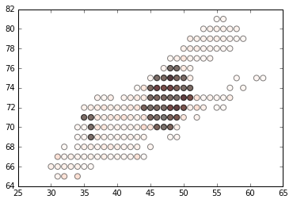

```python
import matplotlib.pyplot as plt
%matplotlib inline

plt.cla()
pxs = [p[0] for p in toll_cells]
pys = [p[1] for p in toll_cells]

plt.scatter(ppxs, ppys, c=pcolors, cmap="Reds", s = 50, alpha=0.5)
plt.scatter(pxs, pys, c="black", s = 50, alpha=0.5)

plt.show()
```

```python
%%html
<style type="text/css">
  .map-canvas { height: 700px; }
</style
```

We now output the CCZ are on a google map

```python
from IPython.core.display import HTML, Javascript
def gmap_init():
    js = """
window.gmap_initialize = function() {};
$.getScript('https://maps.googleapis.com/maps/api/js?v=3&sensor=false&callback=gmap_initialize');
"""
    return Javascript(data=js)

gmap_init()
```

Let's see the solution on a google map.

[figure not shown]

```python
# generate a random id
import uuid
div_id = 'i' + str(uuid.uuid4())

html = """<div height="700" width="500" id="%s" class="map-canvas"/>""" % (div_id)
js = """<script type="text/Javascript">
  (function(){
		var centerlatlng = new google.maps.LatLng(40.759560, -73.978526);
		var myOptions = {
			zoom: 13,
			center: centerlatlng,
			mapTypeId: google.maps.MapTypeId.ROADMAP
		};
		var map = new google.maps.Map(document.getElementById('%s'), myOptions);"""% (div_id)

for toll in toll_cells:
    ii = toll[0]
    jj = toll[1]
    lt = latmin + latsampling*ii
    lg = longmin + longsampling*jj
    sub = "var latlng = new google.maps.LatLng("+str(lt)+", "+str(lg)+");"
    js += sub
    js += """
    var img = new google.maps.MarkerImage('http://chart.apis.google.com/chart?cht=mm&chs=12x16&chco=FFFFFF,0000FF,000000&ext=.png');
		var marker = new google.maps.Marker({
		title: "no implimentation",
		icon: img,
		position: latlng
		});
		marker.setMap(map);
    """
js += """})();
</script>
"""

HTML(html+js)
```